# Returns 6/0/6 Sector Momentum

Tom Marty

## Set up

Load packages and functions.

```r
library(xts)
library(lubridate)
library(PerformanceAnalytics)
library(readr)
library(TTR)
library(RColorBrewer)
library(blotter)
library(FinancialInstrument)
library(parallel)
library(foreach)
library(doParallel)
library(kableExtra)
dataDir <- "~/Desktop/Momentum_tests/Bruce/data"
functionDir <- "/home/ito/Desktop/PhD/Other_Courseware/trademartyr/R"
sapply(file.path(functionDir,list.files(functionDir)),source,echo=FALSE)
Sys.setenv(TZ = "UTC")
```

Load data and create an xts of close prices and another of returns. The `clean_names` function just changes the names of the OHLC data for each of the assets, since the default names from Bloomberg are not recognised by blotter. The function also provides functionality for using adjusted returns and preserving an index membership column if required.

```r
assets <- gsub(".csv","",list.files(dataDir))
load_files(dataDir,list.files(dataDir))
clean_names(assets)
DF <- get_cols(assets,"Close") # Prices
DF_rets <- na.fill(simpleRets(DF),0) # Returns
```

## Strategy parameters

Set strategy parameters.

```r
TopN = 1
nassets=length(assets)
J_m=6
S_m=0
K_m=6
starting_capital=1e06
initEq <- starting_capital/K_m
```

## Generate positions

Perform momentum ranking and get position weights for simple equal-weighted long-short portfolio. Note that we can pass several formation periods to `mom_rank` and it will rank based on acceleration–the average of the momentum of the specified formation periods.

```r
mom <- mom_rank(DF, on="months", n=J_m, S=S_m)
weights <- get_weights_ls(mom, TopN=TopN)
```

We can visualise the proposed entries and exits. This is probably only useful when dealing with a small number of assets. Exits are shown in brackets.

```r
trades <- visualise_trades(weights, K_m)
```

Ranks

| Date | P1 | P2 | P3 | P4 | P5 | P6 |
| --- | --- | --- | --- | --- | --- | --- |
| 1999-07-30 | +XLE -XLP |  |  |  |  |  |
| 1999-08-31 |  | +XLE -XLP |  |  |  |  |
| 1999-09-30 |  |  | +XLI -XLP |  |  |  |
| 1999-10-29 |  |  |  | +XLK -XLB |  |  |
| 1999-11-30 |  |  |  |  | +XLK -XLB |  |
| 1999-12-31 |  |  |  |  |  | +XLK -XLP |
| 2000-01-31 | +XLK -XLU (-XLE +XLP) |  |  |  |  |  |
| 2000-02-29 |  | +XLK -XLP (-XLE +XLP) |  |  |  |  |
| 2000-03-31 |  |  | +XLK -XLU (-XLI +XLP) |  |  |  |
| 2000-04-28 |  |  |  | +XLK -XLP (-XLK +XLB) |  |  |
| 2000-05-31 |  |  |  |  | +XLE -XLB (-XLK +XLB) |  |
| 2000-06-30 |  |  |  |  |  | +XLE -XLB (-XLK +XLP) |
| 2000-07-31 | +XLF -XLB (-XLK +XLU) |  |  |  |  |  |
| 2000-08-31 |  | +XLF -XLB (-XLK +XLP) |  |  |  |  |
| 2000-09-29 |  |  | +XLU -XLK (-XLK +XLU) |  |  |  |
| 2000-10-31 |  |  |  | +XLU -XLK (-XLK +XLP) |  |  |
| 2000-11-30 |  |  |  |  | +XLU -XLK (-XLE +XLB) |  |
| 2000-12-29 |  |  |  |  |  | +XLF -XLK (-XLE +XLB) |
| 2001-01-31 | +XLU -XLK (-XLF +XLB) |  |  |  |  |  |
| 2001-02-28 |  | +XLU -XLK (-XLF +XLB) |  |  |  |  |
| 2001-03-30 |  |  | +XLB -XLK (-XLU +XLK) |  |  |  |
| 2001-04-30 |  |  |  | +XLB -XLK (-XLU +XLK) |  |  |
| 2001-05-31 |  |  |  |  | +XLB -XLK (-XLU +XLK) |  |
| 2001-06-29 |  |  |  |  |  | +XLY -XLP (-XLF +XLK) |
| 2001-07-31 | +XLB -XLK (-XLU +XLK) |  |  |  |  |  |
| 2001-08-31 |  | +XLB -XLK (-XLU +XLK) |  |  |  |  |
| 2001-09-28 |  |  | +XLP -XLK (-XLB +XLK) |  |  |  |
| 2001-10-31 |  |  |  | +XLP -XLK (-XLB +XLK) |  |  |
| 2001-11-30 |  |  |  |  | +XLP -XLE (-XLB +XLK) |  |
| 2001-12-31 |  |  |  |  |  | +XLP -XLK (-XLY +XLP) |

[output cut: 168 more lines]

## Return-based simulation

As with all of our approaches, each of the K overlapping portfolios are simulated separately. The `holding_time` parameter just indicates that we don’t enter a trade unless there is enough time left (in the data) to fulfill the entire holding period.

```r
return_list <- list()
for (start_i in 1:K_m){
  wts_i <- weights_i(weights, start_i, K_m, holding_time=TRUE )[[1]]
  rp <- portfolio_cumulative.return(DF_rets, weights=wts_i)
  return_list[[start_i]] <- initEq*rp
  names(return_list)[start_i] <- paste0("P",start_i)
}
rp_mat <- do.call(cbind, return_list); names(rp_mat) <- names(return_list)
```

## Blotter simulation

When blotter references transaction and portfolio objects using a date range, it adjusts the righthand date such that it has a time of 23:59:59 ( specifically it uses a call like this `.parseISO8601(date_range)$last.time`. If the righthand date happens to be the last date in the data, blotter will throw a warning because it looks like we have asked for a date that isn’t in the asset xts objects. There are a few ways to avoid this the safest is simply to, apped an extra day to to each of the objects. It doesn’t matter that it will be empty as it won’t be referenced.

```r
# Append 1 day extra to avoid annoying blotter range warning
for (i in 1:length(assets)){
  x <- get(assets[i])
  x <- cbind(x,index(x)[nrow(x)]+days(1))
  assign(assets[i], x)
}
```

Set common blotter parameters.

```r
Currency="USD"
currency(Currency)
stock(assets,currency = Currency)
enter_prefer="Close"
exit_prefer="Close"
ind <- index(weights)
initdate <- ind[1] - days(1)
enddate <- ind[length(ind)]
```

We perform the simulation in parallel. Blotter and financial instrument are called within each of the parallel environments, and the currency and stock instruments are loaded into whatever environment the `FinancialInstrument` package sends them. If this is not done, blotter can’t find them when updating the portfolios.

```r
cores <- detectCores()
mycluster <- makeCluster(cores-1,type = "FORK")
registerDoParallel(mycluster)
out <- foreach(
  start_i = 1:K_m) %dopar% {
    library(blotter)
    library(FinancialInstrument)
    currency(Currency)
    stock(assets,currency = Currency)
    place_transactions(initEq, assets, Currency, ind, start_i=start_i, K_m,
                             wts=weights, initdate, enddate, holding_time=TRUE)
  }
stopCluster(mycluster)
```

### Extract blotter results

```r
# Load portfolios into environment
portf_names <- list()
for (i in 1:length(out)){
  portf_names[[i]] <- names(out[[i]])
  put.portfolio(names(out[[i]]),out[[i]][[1]])
}
# Create combined account from individual portfolios
accountName=paste0("acct_",J_m,S_m,K_m)
suppressWarnings(rm(list=c(paste0("account.",accountName)), pos=.blotter))
initAcct(name=accountName, portfolios=portf_names, initDate=initdate,
         initEq=starting_capital)
updateAcct(accountName)
updateEndEq(accountName)
```

We can also view the actual transactions to make sure they are consistent with what we expected.

```r
txns <- txn_pretty(portfolio_list = unlist(portf_names))
```

| Date | Portfolio | Symbol | Txn.Qty | Txn.Price | Txn.Fees | Txn.Value | Txn.Avg.Cost | Net.Txn.Realized.PL |
| --- | --- | --- | --- | --- | --- | --- | --- | --- |
| 1999-07-30 | portfolio_1 | XLE | 7867 | 21.1855 | 0 | 166666.33 | 21.1855 | 0.0000 |
| 1999-07-30 | portfolio_1 | XLP | -9807 | 16.9941 | 0 | -166661.14 | 16.9941 | 0.0000 |
| 1999-08-31 | portfolio_2 | XLE | 7781 | 21.4171 | 0 | 166646.46 | 21.4171 | 0.0000 |
| 1999-08-31 | portfolio_2 | XLP | -9642 | 17.2851 | 0 | -166662.93 | 17.2851 | 0.0000 |
| 1999-09-30 | portfolio_3 | XLI | 7868 | 21.1810 | 0 | 166652.11 | 21.1810 | 0.0000 |
| 1999-09-30 | portfolio_3 | XLP | -10598 | 15.7260 | 0 | -166664.15 | 15.7260 | 0.0000 |
| 1999-10-29 | portfolio_4 | XLB | -9990 | 16.6829 | 0 | -166662.17 | 16.6829 | 0.0000 |
| 1999-10-29 | portfolio_4 | XLK | 4748 | 35.0953 | 0 | 166632.48 | 35.0953 | 0.0000 |
| 1999-11-30 | portfolio_5 | XLB | -10133 | 16.4466 | 0 | -166653.40 | 16.4466 | 0.0000 |
| 1999-11-30 | portfolio_5 | XLK | 4324 | 38.5403 | 0 | 166648.26 | 38.5403 | 0.0000 |
| 1999-12-31 | portfolio_6 | XLK | 3746 | 44.4896 | 0 | 166658.04 | 44.4896 | 0.0000 |
| 1999-12-31 | portfolio_6 | XLP | -10438 | 15.9668 | 0 | -166661.46 | 15.9668 | 0.0000 |
| 2000-01-31 | portfolio_1 | XLE | -7867 | 20.3995 | 0 | -160482.87 | 20.3995 | -6183.4620 |
| 2000-01-31 | portfolio_1 | XLK | 4051 | 41.7542 | 0 | 169146.26 | 41.7542 | 0.0000 |
| 2000-01-31 | portfolio_1 | XLP | 9807 | 16.1076 | 0 | 157967.23 | 16.1076 | 8693.9055 |
| 2000-01-31 | portfolio_1 | XLU | -11092 | 15.2518 | 0 | -169172.97 | 15.2518 | 0.0000 |
| 2000-02-29 | portfolio_2 | XLE | -7781 | 19.5359 | 0 | -152008.84 | 19.5359 | -14637.6172 |
| 2000-02-29 | portfolio_2 | XLK | 3934 | 46.1412 | 0 | 181519.48 | 46.1412 | 0.0000 |
| 2000-02-29 | portfolio_2 | XLP | 9642 | 14.2228 | 0 | 137136.24 | 14.2228 | 29526.6966 |
| 2000-02-29 | portfolio_2 | XLP | -12765 | 14.2228 | 0 | -181554.04 | 14.2228 | 0.0000 |
| 2000-03-31 | portfolio_3 | XLI | -7868 | 21.6451 | 0 | -170303.65 | 21.6451 | 3651.5388 |
| 2000-03-31 | portfolio_3 | XLK | 3610 | 50.0121 | 0 | 180543.68 | 50.0121 | 0.0000 |
| 2000-03-31 | portfolio_3 | XLP | 10598 | 14.7571 | 0 | 156395.75 | 14.7571 | 10268.4022 |
| 2000-03-31 | portfolio_3 | XLU | -12151 | 14.8607 | 0 | -180572.37 | 14.8607 | 0.0000 |
| 2000-04-28 | portfolio_4 | XLB | 9990 | 15.4195 | 0 | 154040.80 | 15.4195 | 12621.3660 |
| 2000-04-28 | portfolio_4 | XLK | -4748 | 45.4186 | 0 | -215647.51 | 45.4186 | 49015.0284 |
| 2000-04-28 | portfolio_4 | XLK | 5026 | 45.4186 | 0 | 228273.88 | 45.4186 | 0.0000 |
| 2000-04-28 | portfolio_4 | XLP | -14691 | 15.5395 | 0 | -228290.79 | 15.5395 | 0.0000 |
| 2000-05-31 | portfolio_5 | XLB | 10133 | 14.9329 | 0 | 151315.08 | 14.9329 | 15338.3221 |
| 2000-05-31 | portfolio_5 | XLB | -12812 | 14.9329 | 0 | -191320.31 | 14.9329 | 0.0000 |

[output cut: 750 more lines]

## Compare results

We compare each of the individual K portfolios.

```r
# Me - blotter
acct <- getAccount(accountName)
# Bruce - blotter
b_rets <- read_csv(file.path("~/Desktop/Momentum_tests/Bruce",
                             "Bruces_returns.csv"))
b_rets <- xts(b_rets[,-1],order.by = b_rets$X1)
b_eq <- initEq*cumprod(1+b_rets[,1:K_m])
```

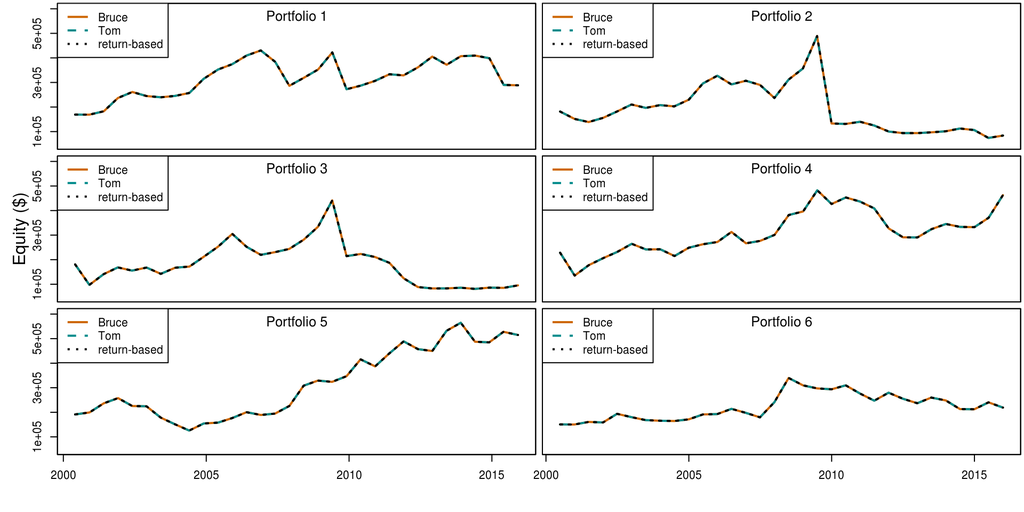

```r
# Compare individual portfolios
par(mfrow = c(K_m/2, 2))
par(oma = c(4, 4, 0, 0))
par(mar = c(0.25, 0.25, 0.25,.25))
ylim=c(0.5e05,6e05)
for(n in 1:K_m){
  b_ind <- index(b_rets)[b_rets[,n]!=0]
  eq_t <- out[[n]][[1]]$summary$Gross.Trading.PL
  eq_t[1] <- initEq
  eq_r <- rp_mat[,n]
  Yaxt="n"
  Xaxt="n"
  Ylab=""
  if(n %% 2 != 0){
    Yaxt="t"
  }
  if(n > K_m-2){
    Xaxt="t"
  }
  plot.zoo(cbind(b_eq[,n],cumsum(eq_t), eq_r)[b_ind],
           col =c("darkorange3","cyan4","black") ,screens = 1,
           lty=c("solid", "dashed", "dotted"),
           lwd=2, xlab="", ylab="", xaxt=Xaxt, yaxt=Yaxt, ylim = ylim)
  legend("topleft",legend = c("Bruce","Tom", "return-based"),lwd=2,
         col=c("darkorange3","cyan4", "black"),
         lty=c("solid","dashed","dotted"), cex=1)
  if(n==trunc(K_m/2)){
    mtext(paste("Equity ($)"), side = 2, line = 2.2, adj = 0.5, cex = 1,
          col = "black")
  }
  mtext(paste("Portfolio",n), side = 3, line = -1.5, adj = 0.5, cex = .8,
        col = "black")
}
```

Here we compare combined portfolios. Bruces looks different because he updated his portfolios on different dates (only at transactions), so the curve only shows fluctuations from one portfolio at a time (and only on months).

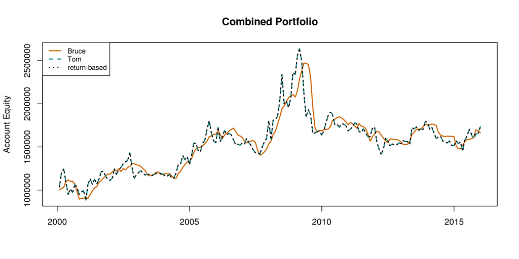

```r
par(mfrow = c(1,1))
t_port <- acct$summary$End.Eq
b_port <- xts(rowSums(b_eq),order.by=index(b_eq))
r_port <- xts(rowSums(rp_mat),index(rp_mat))
plot.zoo(cbind(b_port,t_port, r_port)[index(b_port)],
         col =c("darkorange3","cyan4","black") ,screens = 1,
         lty=c("solid", "dashed", "dotted"),
         lwd=2, xlab="", ylab="Account Equity", main = "Combined Portfolio")
legend("topleft",legend = c("Bruce","Tom", "return-based"),lwd=2,
       col =c("darkorange3","cyan4", "black"), lty=c("solid","dashed","dotted"),
       cex=0.8)
```

Here we compare Tom’s blotter results with the return-based results at a greater granularity (daily).

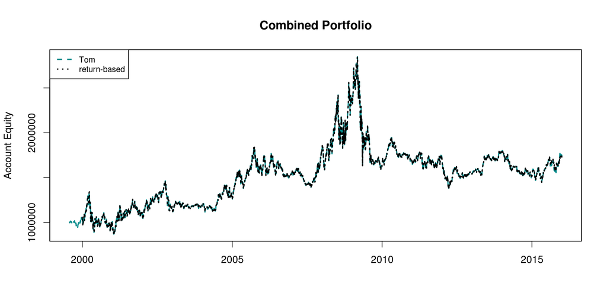

```r
plot.zoo(cbind(t_port, r_port),
         col =c("cyan4","black") ,screens = 1,
         lty=c("dashed", "dotted"),
         lwd=2, xlab="", ylab="Account Equity", main = "Combined Portfolio")
legend("topleft",legend = c("Tom", "return-based"),lwd=2,
       col =c("cyan4", "black"), lty=c("dashed","dotted"),
       cex=0.8)
```